# Introductory Workshop on Epidemiological and Statistical Analysis Using R

Workflow and Analysis

Author

Assoc Prof Dr Kamarul Imran Musa

# Introduction

## About myself

My name is Kamarul Imran, but just call me KIM. I hold the position of Associate Professor in Epidemiology and Statistics at the School of Medical Sciences, Universiti Sains Malaysia. Currently,

- Head, Department of Community Medicine, School of Medical Sciences,
- Adjunct Assoc Prof at School of Medical and Life Sciences, Sunway University.
- Treasurer, Malaysian Association of Epidemiology

My academic profile is available [here](http://www.medic.usm.my/jpm/index.php/en/academic-information/587-prof-madya-dr-kamarul-imran-musa). Previously, I also taught at Monash Universiti Malaysia for the business analytics course, a Master programme.

## Research profiles

My research profile at Google Scholar is available [here](https://scholar.google.com/citations?user=XVf2_QcAAAAJ&hl=en&authuser=1.)

My SCOPUS author ID is 57194536466

[figure not shown]

## Research interests

My research interests include medical epidemiology, statistical modelling and machine learning. In 2019, I was awarded with 2 major grants

- the FRGS grant (RM125,000) to understand the roles of mammography images and clinical conditions on the performance of machine learning and statistical models to predict breast cancer.
- the Newton-Ungku Omar grant (GBP100,000 + RM480,000).

I can be connected by

- Email: drkamarul@usm.my
- Twitter: @kamarul_imran
- [Personal webpage](https://myanalytics.com.my/)

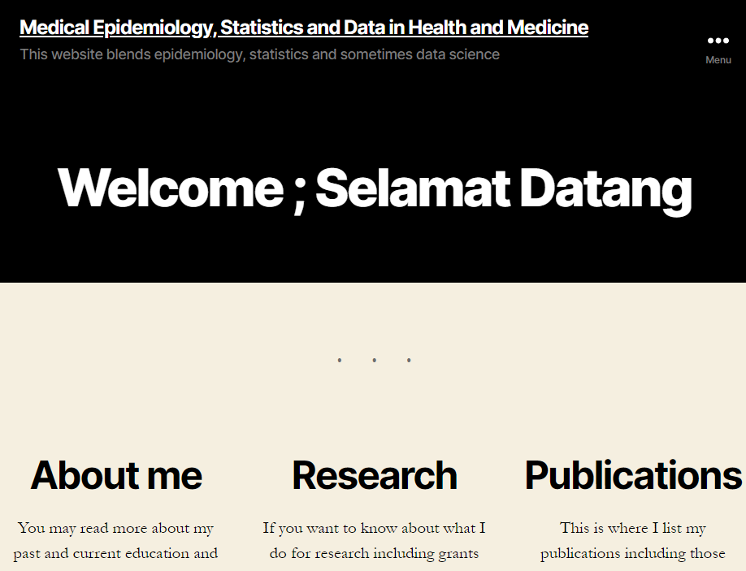

## Books

[figure not shown]

[figure not shown]

# Introduction to workshop

Length of workshop : 180 minutes

Approaches:

- Theory
- Hands-on
- Tips

We are using [this URL](https://sites.google.com/view/epidstat/home) as our workshop webpage. Please,take a few minutes to register a free Posit Cloud account [here](https://posit.cloud/plans/free).

The very **important to follow these steps**

- click this [link](https://posit.cloud/spaces/386007/join?access_code=pFJS6kctkQHzrVgGNRpgG_LfQIRXOqe5vMgb6k6Q)
- Accept to be a **member**
- Click New Project
- Click New RStudio Project

Wait for 1-2 minutes for Posit to prepare the environment.

Next,

- click File
- Click new R script

Useful keyboard shortcuts to run each line of codes

- CRTL - ENTER (for Windows users)
- CMD - ENTER (for MacOS users)

# Data analysis workflow (40 minutes)

Based on my experience, this workflow will help you be effective

- Read : Read data into R
- Explore : Explore data using graphs and tables
- Assume : Identify assumptions for the analysis
- Analyze : Analyze data based on objectives and proposed methods
- Assess : Assess results based on assumptions. Identify limitations of analysis
- Present : Present results, data and codes